# ProgrammingLesson_18-10

### Concepts being planned to be covered

1. External libraries
2. Operator overloading
3. Looking at a sample dataset

**External libraries that needs to be revised**

1. Matplotlib

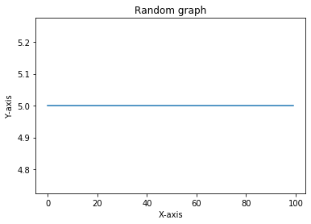

```python
%matplotlib inline
import matplotlib.pyplot as plt
#help(plt.plot)
x = range(0,100)

y = []
constant = 5
for i in x:
    y.append(constant)
#plt.figure()
plt.plot(x,y)
plt.title("Random graph")
plt.xlabel("X-axis")
plt.ylabel("Y-axis")
#plt.show()
```

```python
dir(graph)
```

[output not shown]

*A brief overview about different ways to import. such as* import and specific imports.*

**Checkpoint : Do we delve into Machine Learning or Data cleaning and exploration?**

Now that we have looked at different ways to import the data, let's actually import and use one library.

**Pandas**  
The most popular library in data science. It is used right from importing the data to all further explorations

```python
import pandas as pd
dir(pd)
```

[output not shown]

[output cut: 85 more lines]

[output not shown]

The basic object and most important element in pandas is a Dataframe. **There is another element also known as Series.** As the you can guess from the name, it is a table like format for storing your data. All the accompanies methods written in pandas are applied to this dataframe object.

Now let's look at some of methods within pandas.

```python
dataset = pd.read_csv()
dataset.describe()
```

[output not shown]

Let's see what about these methods do.

**An important element seen in data science projects is using using your intuition along side your programming knowlegde**

```python
dataset.columns
```

[output not shown]

Let's say in the real life example, and we only want use parts of the dataset that we feel are relevant. There are two ways to create a subset of the dataset that is being explored.

1. Through selecting certain columns (Such as to select features)
2. Selecting a particular column through dot notation. (Such as to select the target variable)

```python
y = dataset.columnnanme
features = ['col1', 'col2', 'col5']
x = dataset[features]
```

*Now visually inspect x*

Now let's look at another library of interest to import from.  
**scikit-learn**  
This library has many ML models for the ease of our implementation.

```python
from sklearn.tree import DecisionTreeRegressor
```

In anycase let's go back to pandas, and explore some of its ulities together.

Lt's different parts of panda's functionalities

1. Creating a. Contructing a dataframe/Examples b. Constructing a series/Examples
2. Reading a. From a csv into a dataframe
3. Writing a. Dataframe or series to a csv file
4. Accessing a. 2 ways - Object way or Dictionary way. Latter way has an advantage b. One values frame["col"][indx] - col, row c. more advanced way is using .iloc and .loc - row, col d. iloc - position[exclusively], loc - labelname[inclusive]
5. Index a. not immutable b. changing the index field to one of the column names
6. Conditional Selection a. Creates a list of true or false b. useful for .loc function c Two built-in condiinal selectors isin or isnull
7. Assigning an index or values. - creates a new column - **Not fuly clear**
8. Summary functions - intention to restructure the data for the model training. 1.

```python
#Functions

number = int(input("Enter a number till which you want to display \n"))
for i in range(1, number):
    print(i)
```

```
Enter a number till which you want to display
15
1
2
3
4
5
6
7
8
9
10
11
12
13
14
```

```python
def printTill(number):
    output = []
    for i in range(1, number):
        output.append(i)
    return output
```

```python
myvariable = printTill(16)
```

```python
print(myvariable)
```

```
[1, 2, 3, 4, 5, 6, 7, 8, 9, 10, 11, 12, 13, 14, 15]
```

```python
myvariable.append(5)
```

```python
myvariable
```

```
[1, 2, 3, 4, 5, 6, 7, 8, 9, 10, 11, 12, 13, 14, 15, 5]
```

```python
import pandas as pd
```

```python
# Input data
covid = pd.read_csv("owid-covid-data.csv")
```

```python
round(covid.mean(),2)
```

```
total_cases                          130732.53
new_cases                              1588.70
new_cases_smoothed                     1568.52
total_deaths                           5998.60
new_deaths                               44.37
new_deaths_smoothed                      44.38
total_cases_per_million                2407.14
new_cases_per_million                    28.62
new_cases_smoothed_per_million           27.80
total_deaths_per_million                 83.58
new_deaths_per_million                    0.58
new_deaths_smoothed_per_million           0.58
new_tests                             25039.19
total_tests                         1795304.40
total_tests_per_thousand                 61.24
new_tests_per_thousand                    0.78
new_tests_smoothed                    24143.97
new_tests_smoothed_per_thousand           0.76
tests_per_case                          182.44
positive_rate                             0.07
stringency_index                         57.04
population                         87263111.82
population_density                      361.05
median_age                               31.27
aged_65_older                             9.23
aged_70_older                             5.83
gdp_per_capita                        20793.09
extreme_poverty                          12.25
cardiovasc_death_rate                   251.93
diabetes_prevalence                       8.05
female_smokers                           10.78
male_smokers                             32.64
handwashing_facilities                   52.29
hospital_beds_per_thousand                3.10
life_expectancy                          73.99
human_development_index                   0.72
dtype: float64
```